# HultenRangeMaps

```r
library(HultenRangeMaps)
```

## Georeferencing scanned and aligned maps

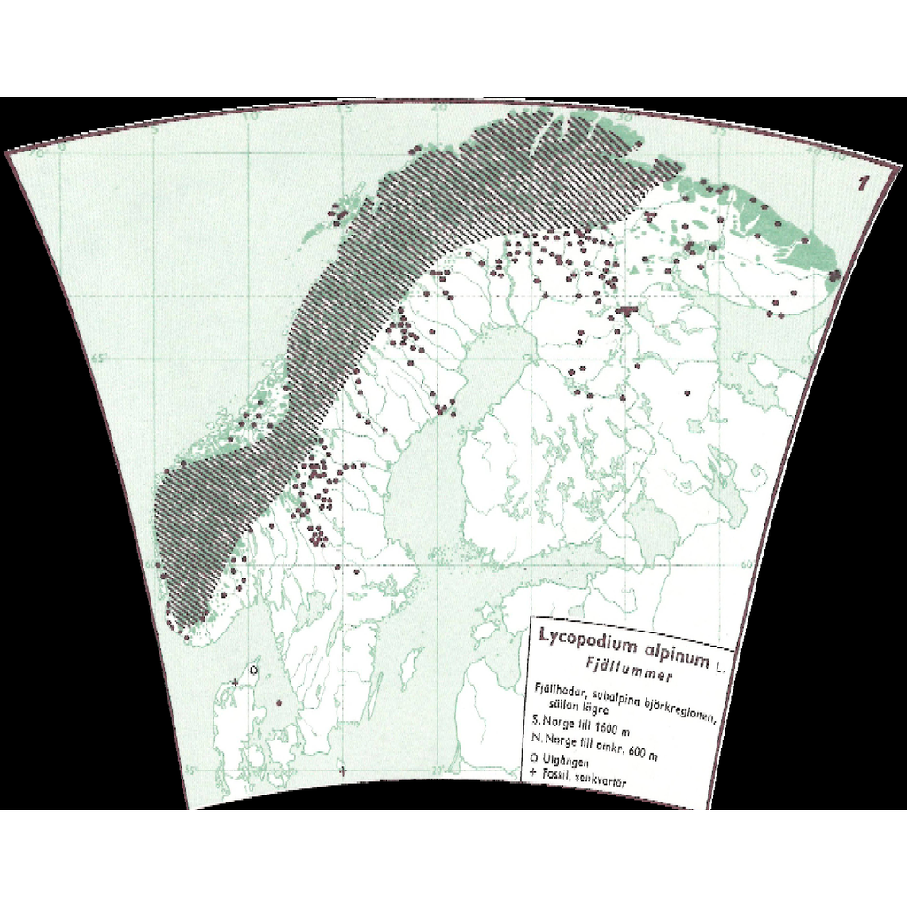

```r
# ground control points
gcps <- matrix(c(127.095, 54.15, 0, 70,
                 566.228, 149.247, 10, 70,
                 1014.47, 185.013, 20, 70,
                 1459.87, 148.411, 30, 70,
                 1894.52, 43.1847, 40, 70,
                 195.246, 743.443, 5, 65,
                 738.246, 823.491, 15, 65,
                 1286.45, 822.073, 25, 65,
                 1823.77, 737.613, 35, 65,
                 2090.39, 665.129, 40, 65,
                 47.442, 1378.15, 5, 60,
                 688.768, 1474.27, 15, 60,
                 1334.66, 1472.54, 25, 60,
                 1971.58, 1374.53, 35, 60,
                 267.179, 2078.65, 10, 55,
                 1011.56, 2136.63, 20, 55),
               ncol = 4, byrow = TRUE) # the gcps are retrived from the Qgis gdal script, minus the first "-gcp".

# since the gdal functions require a file path, generate a temporary directory
temp <- tempdir()

# save the aligned example map in the temporary directory
jpeg::writeJPEG(aligned_map,paste0(temp,"/aligned_map.jpg"))

# convert the aligned example map a to georeferenced GEOTiff by providing ground control points (translate) and reproject to WGS84 - World Geodetic System 1984 (EPSG:4326) (warp)
gdalUtilities::gdal_translate(paste0(temp,"/aligned_map.jpg"), paste0(temp,"/gpc_map.tif"), of="GTiff", gcp= gcps)
gdalUtilities::gdalwarp(paste0(temp,"/gpc_map.tif"), paste0(temp,"/ref_map.tif"), t_srs = "EPSG:4326", r="near",  order=3)

# import and plot map
ref_map <- raster::stack(paste0(temp,"/ref_map.tif")) # import GEOTiff
raster::plotRGB(ref_map) # plot map
```

## Digitise scanned and aligned range maps

The maps were printed in only two colors (see the map above and Figure 1-7 in Arnell et al. XXX) with distribution areas represented in dark red and geographical borders represented in green. We can therefore extract the range data from the georeferenced raster images by extracting the red pixel values (Figure 8 et al. XXX).  
The function mapDig() takes a scanned range map (raster stack) with three bands (Red-Green-Blue) and extracts the range information by taking the green raster band and setting pixel values 1-150 to 1 and all other to 0. The pixel range 0-150 in green raster band represents the dark red areas in the scanned map.

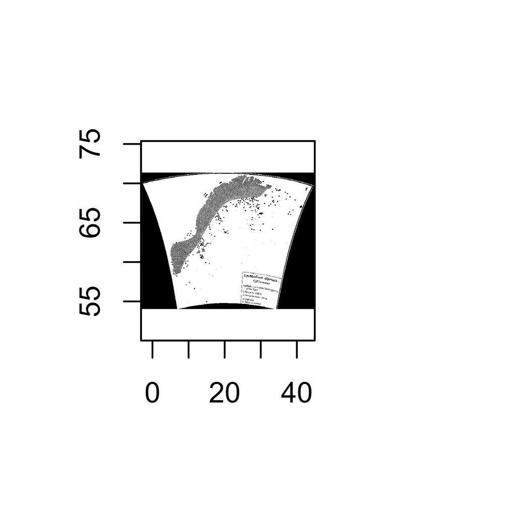

```r
dig_map <- mapDig(ref_map) # digitise the georeferenced map
raster::plot(dig_map, col="black",legend=F) # plot map
```

## Automated data cleaning and conversion from raster to spatial features

After extracting the range data, we remove (most of) the border, map number and legend (also represented in red on the maps). To remove small digitalization errors we identify ‘clumps’ of connected cells and remove clumps with <15 cells. We then convert rasters to polygon spatial features.  
The function mapCleanConvert() performs the steps described above.

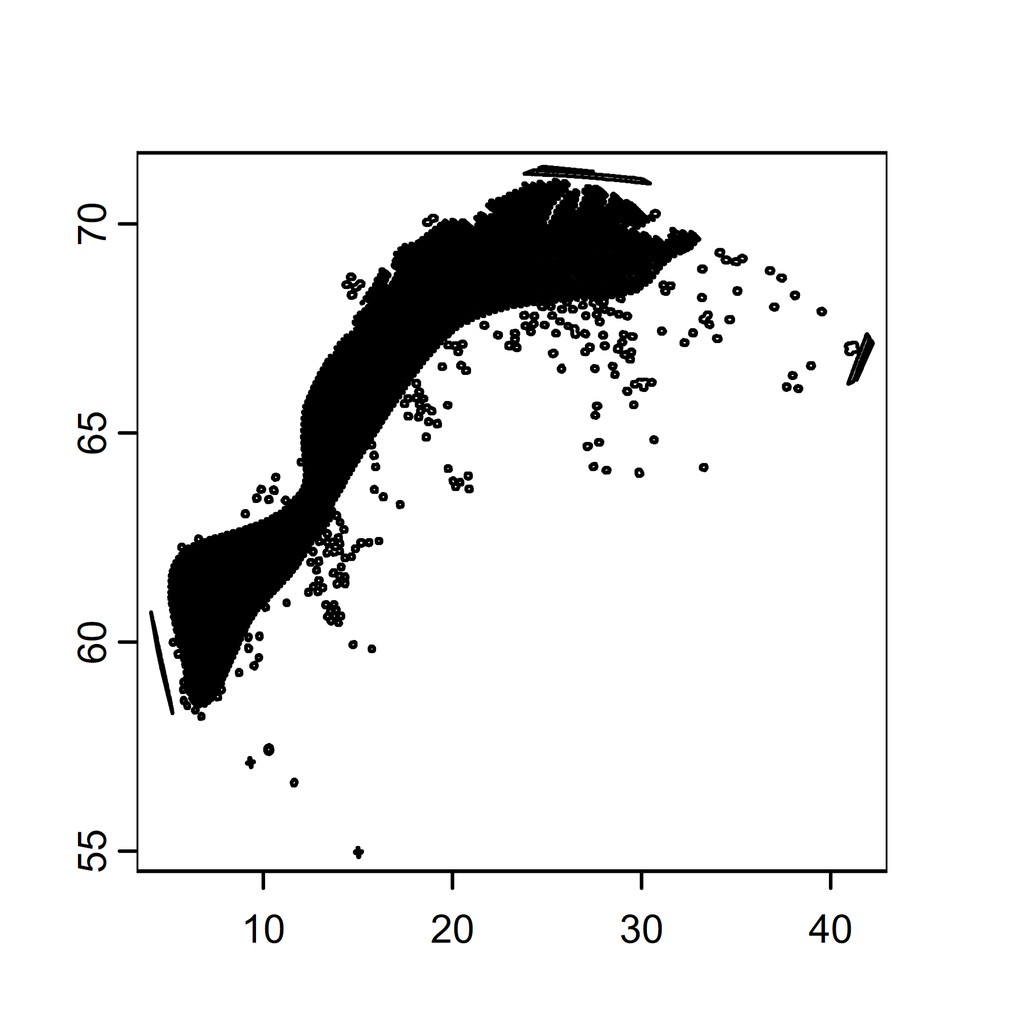

```r
clean_map <- mapCleanConvert(dig_map)
terra::plot(clean_map)
```

## Manual data cleaning and updated scientific nomenclature

The cleaned map may still contain small digitization errors (part of the map border), as well as map symbols that represent non-presence points, e.g. locally extinct populations (open circle) and fossil records (crosses). These have been manually removed from the maps in the database. Please refer to the description in Arnell et al. XXX and the file HultenMetadata.csv in the database (Arnell et al. XXX) for information on manual editing as well as updated scientific nomenclature.

## Example: how to match the digitized distribution maps to the Swedish National grid

To aid spatial analyses of our data, we provide an example on how to match the digitized distribution maps to the Swedish 10×10 km National grid, commonly employed in Swedish regional plant inventories. The outcome is a list of data frames with historical presence per grid cell per species.

There are two main types of symbols representing a species’ range in the original maps. Hatched areas representing areas where the species is common to less common and dots representing isolated finds (Figure 3 in Arnell et al. XXX). Given the scale of the original maps, the size of the dots representing isolated finds is approximately 16 km on the ground. This means that if we overlap the digitized and cleaned range maps (polygon features) with the 10×10 km Swedish National grid one ‘isolated find’ polygon will commonly overlap with 4-6 10×10 km grid cells, thus potentially over representing the historical range of a species. We overcome this by identifying ‘isolated finds’ polygons (features with circular shapes and of the right size) and reduce the area of these polygons by a 5000 m negative buffer.

The function rangeToGrid() performs the steps described above. The function is designed to take a file path to the directory where the database (XXX) is stored. In this example we save an example database map of *Lycopodium alpinum* in a temporary directory.

**NOTE:** for the function to work the grid needs to be a polygon spatial feature with gridIDs stored in an attribute column named ‘gridID’

```r
# save the example database map in the temporary directory
geojsonio::geojson_write(database_map, file = paste0(temp,"\\Lycopodium alpinum_0001.geojson"))
```

```
#> Success! File is at C:\Users\frar7633\AppData\Local\Temp\RtmpOQOuFy\Lycopodium alpinum_0001.geojson
```

```r
# when we retrieve maps from a temporary directory, we need to add '/' to the file path. This is not necessary if you have stored the database (XXX) in a folder on your computer
list_histRange <- rangeToGrid(path = paste0(temp,"/"), pattern="*.geojson", grid=SweNationalGrid)
```

```
#> start processing of Lycopodium alpinum (number 1 out of 1 species)
#> transform range map coordinates to grid coordinate reference system
#> identify and reduce size of polygons representing 'isolated finds'
#> match the (national) grid with the species' historical range
#> create dataframe with historical precence per grid
#> ------------------
```

```r
# combine data frames (in this example there is only one)
hist_pres <- do.call(rbind, list_histRange)
rownames(hist_pres) <- NULL
```

```r
# historical presence per species per grid
head(hist_pres)
```

```
#>   gridID     scientificName histPres
#> 1  11F6i Lycopodium alpinum        1
#> 2  11E8g Lycopodium alpinum        1
#> 3  11E8i Lycopodium alpinum        1
#> 4  13D0c Lycopodium alpinum        1
#> 5  13D0e Lycopodium alpinum        1
#> 6  13D0g Lycopodium alpinum        1
```

## Historical biodiversity of vascular plants in Sweden

In the example above we match the historical distribution area of one species to the Swedish national grid. Included in the database (and in this package) is a file ‘histPresSweNationalGrid.csv’ with per grid historical presence of all species in the database produced using the method above. This can be used to produce a map of the historical biodiversity of vascular plants in Sweden.  
We exclude grid cells with 50% or more land surface outside Sweden’s national borders and grid cells covered to 80% or more by sea surface or waterways.

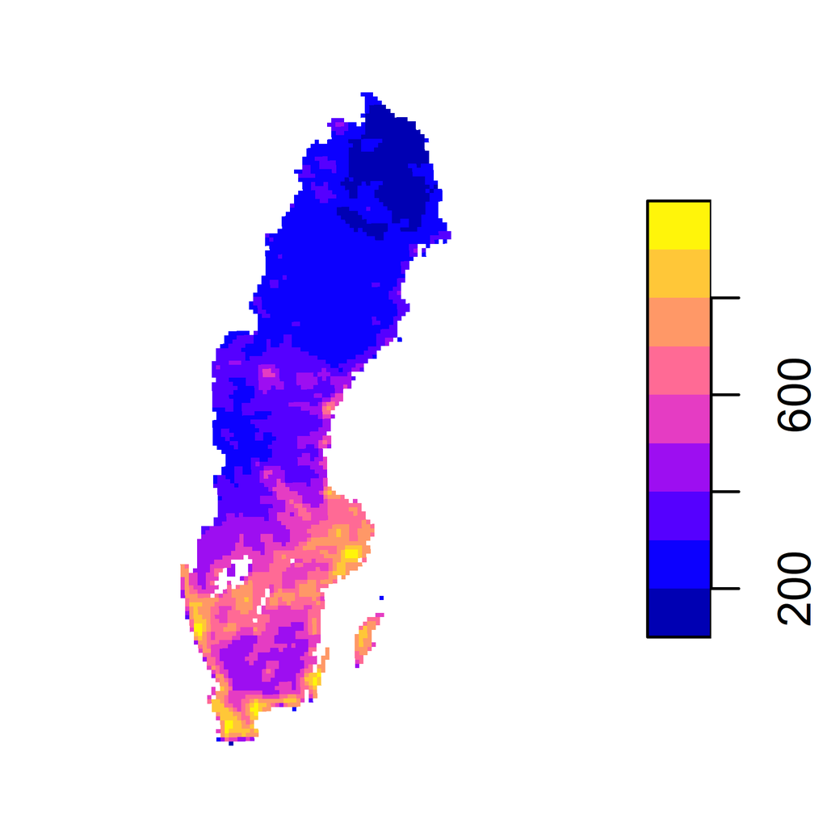

```r
# the Swedish national grids with enough land surface
landGridsMap <- SweNationalGrid[SweNationalGrid$gridID %in% land_grids,]

# count number of species per grid
hist_biodiv <- setNames(aggregate(histPres ~ gridID, histPresSweNationalGrid, sum),c("gridID", "histBiodiv"))

# add historical biodiversity data to map
histBiodivMap <- merge(landGridsMap, hist_biodiv)

#plot!
plot(histBiodivMap["histBiodiv"], border=NA, main="" )
```

## Bonus example: match the digitized distribution maps to the European 10x10 grid in Scandinavia

To illustrate that the function can match the historical range data to any grid data (as long as the grid is a polygon spatial feature with one attribute column named ‘gridID’), we have included another example. Included in this package is a list of files with the historical ranges of the Scandinavian *Galium* species (N=14) from the database as well as the part of the European 10x10 that covers Scandinavia and Finland.  
In this example we store the *Galium* historical range maps in a temporary folder, match their distributions to the European grid and plot the number of *Galium* species per grid in Scandinavia based on their historical distributions.

```r
# add Galuim species ranges to the temporary folder
for (i in names(galium_list)){
  sf::write_sf(galium_list[[i]],paste0(temp,"\\",i))
}

# match historical distributions of Galium species to the European grid (this will take some time since there are 14 Galium species in the database)
list_histRangeScan <- rangeToGrid(paste0(temp,"/"),pattern="*Galium*", grid = ScanGrid)

# combine data frames
hist_pres_scan <- do.call(rbind, list_histRangeScan)
rownames(hist_pres_scan) <- NULL
```

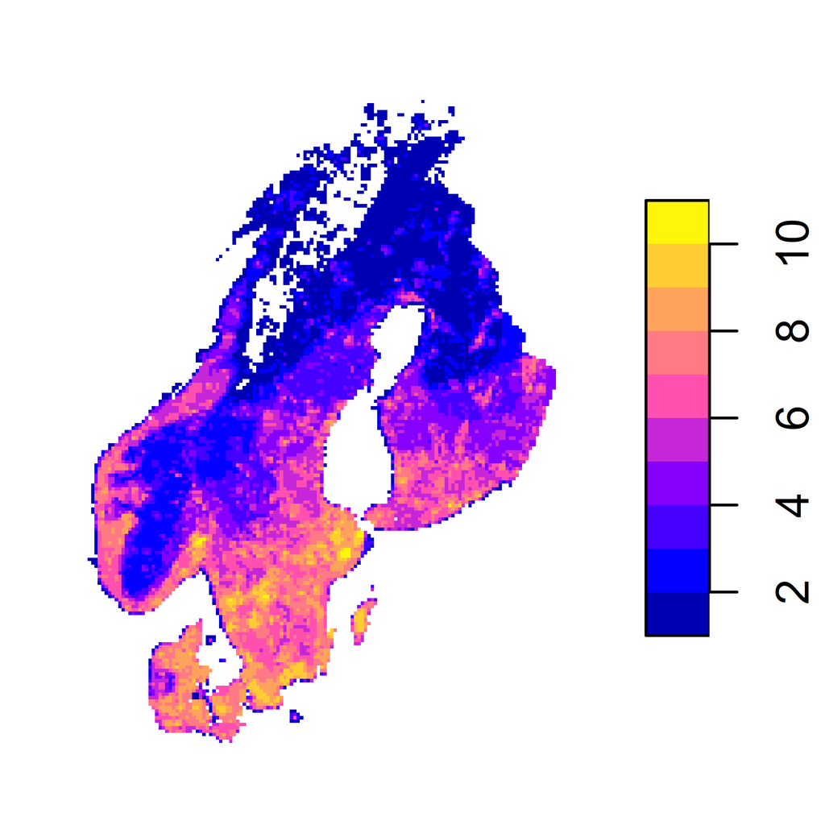

```r
# count number of species per grid
hist_Galium_biodiv_scan <- setNames(aggregate(histPres ~ gridID, hist_pres_scan, sum),c("gridID", "histBiodiv"))

# add historical biodiversity data to map
histGaliumBiodivScan <- merge(ScanGrid, hist_Galium_biodiv_scan, all.x=T)

# plot!
plot(histGaliumBiodivScan["histBiodiv"], border=NA, main="")
```

## Fix file names

In the Swedish Taxonomic Database Dyntaxa, hybrid species are denoted by the symbol ×. To facilitate file handling the symbol × has been replaced by the letter x in the database file names. The function fixFileNames() changes the letter x in the file names back the symbol × so that the file names are identical to the Dyntaxa scientific names.  
Changing x to × is also done in the function rangeToGrid() to insure that the file with per species per grid historical presence matches the scientific names in the Dyntaxa database.

```r
path <- ".../HultenRangeMapDatabase/"
fixFileNames(path, pattern = "*.geojson")
```

## Guide: how to install packages from local repositories

To insure reproducability, we have created a ‘miniCRAN’ repository with all the packages that the functions in HultenRangeMaps require (and the packages that they in turn require). The repository can be downloaded [here](https://github.com/ArnellM/HultenRangeMaps_miniCRAN_June2025.git).  
First, download the repository to your computer. Then, install the packages from your local repository using the code below.

```r
# list of packages that the functions in HultenRangeMaps require
pkgs <- c("dplyr", "gdalUtilities", "geojsonio", "gtools", "igraph", "jpeg", "raster", "sf", "terra", "tidyr")

# path to where you have downloaded the local miniCran repository
pth <- "C:/miniCran/HultenRangeMaps_miniCRAN_June2025"

# install packages from your local miniCRAN repository
install.packages(pkgs,
                 repos = paste0("file:///", pth),
                 type = "source")
```

## References

Hultén, E. (1971). Atlas of the distribution of vascular plants in northwestern Europe (2nd ed.). Generalstabens Litografiska Anstalts Förlag.

Sorzano, C. O. S., Thevenaz, P., & Unser, M. (2005). Elastic registration of biological images using vector-spline regularization. IEEE Transactions on Biomedical Engineering, 52(4), 652–663. IEEE Transactions on Biomedical Engineering. https://doi.org/10.1109/TBME.2005.844030

Arganda-Carreras, I., Sorzano, C. O. S., Marabini, R., Carazo, J. M., Ortiz-de-Solorzano, C., & Kybic, J. (2006). Consistent and Elastic Registration of Histological Sections Using Vector-Spline Regularization. In R. R. Beichel & M. Sonka (Eds.), Computer Vision Approaches to Medical Image Analysis (Vol. 4241, pp. 85–95). Springer Berlin Heidelberg. https://doi.org/10.1007/11889762_8

Schindelin, J., Arganda-Carreras, I., Frise, E., Kaynig, V., Longair, M., Pietzsch, T., Preibisch, S., Rueden, C., Saalfeld, S., Schmid, B., Tinevez, J.-Y., White, D. J., Hartenstein, V., Eliceiri, K., Tomancak, P., & Cardona, A. (2012). Fiji: An open-source platform for biological-image analysis. Nature Methods, 9(7), Article 7. https://doi.org/10.1038/nmeth.2019